# Agromorphological diversity and promising accessions of common bean (Phaseolus vulgaris) in the northeastern Peruvian Andes

Author

Huanambal-Gálvez et al. 2026

# 1 Project Setup

# 2 Data import

## 2.1 Data

Phenotypic data from common bean accessions are available in the following dataset: Google Sheets.

> https://docs.google.com/spreadsheets/d/1uctK0JUrazXonQsA-Drt70Vwbv6JnfiKOoGIpcJGGMI/edit?gid=644660855#gid=644660855

## 2.2 Import data

### 2.2.1 Descriptors

Descriptors evaluated in the accessions and the two checks.

| descriptor | abbreviatio_sp | descriptors | abbreviatio_en | cat_es | cat_en |
| --- | --- | --- | --- | --- | --- |
| Color cotiledón emergente | cce | Emergent cotyledon color | ECC | Purpura; Rojo; Verde; Blanco; Verde muy palido | Purple; Red; Green; White; Very pale green |
| Hábito de crecimiento | tcvmfp | Growth habit | GH | Determinado arbustivo; Indeterminado arbustivo; Indeterminado postrado; Indeterminado trepador | Determinate bush; Indeterminate bush; Indeterminate prostrate; Indeterminate climbing |
| Color del pétalo estandarte al 90% de floración fisiológica | Cpe | Standard petal color at 90% flowering | SPC | Blanco; Verde; Lila; Blanco con borde lila; Blanco con rayas rojas; Lila oscuro con borde exterior morado; Lila oscuro con manchas violaceas; Rojo carmin; Morado; Blanco con vetas lila | White; Green; Lilac; White with lilac margin; White with red stripes; Dark lilac with purple outer margin; Dark lilac with violet spots; Carmine red; Purple; White with lilac veins |
| Color de las alas al 90% de floración fisiológica | cda | Wing petal color at 90% flowering | WPC | Blanco; Verde; Lila; Blanco con rayas de carmin; Fuertemente veteado en rojo a lila oscuro; De rojo liso a lila oscuro; Lila con vetas lilas oscuras; Morado; Lila claro; Rojo | White; Green; Lilac; White with carmine stripes; Heavily veined from red to dark lilac; Solid red to dark lilac; Lilac with dark lilac veins; Purple; Light lilac; Red |
| Posición de las vainas al 50% de madurez fisiológica | pv | Pod position at 50% physiological maturity | PP | Base; Centro; Top; Combinacion de 1 2 3; Combinacion 2 3 | Base; Center; Top; Combination 1–2–3; Combination 2–3 |
| Curvatura de la vaina al 50% de madurez fisiológica | cva | Pod curvature at 50% physiological maturity | PC | Recto; Ligeramente curvado; Curvo; Recurvado | Straight; Slightly curved; Curved; Recurved |
| Color de la vaina al inicio de la madurez fisiológica | cv | Pod color at the onset of physiological maturity | PCO | Purpura oscuro; Rojo carmin; Raya morada sobre verde; Raya carmin sobre verde; Raya de color rojo palido sobre verde; Rosa oscuro (rosa); Verde normal; Verde brillante; Verde opaco a gris plateado; Do… | Dark purple; Carmine red; Purple stripe on green; Carmine stripe on green; Pale red stripe on green; Dark pink (rose); Normal green; Bright green; Dull green to silvery grey; Golden yellow; Pale yello… |
| Color de la vaina al 90% de madurez fisiológica | cvmf | Pod color at 90% physiological maturity | PC90 | Purpura oscuro; Rojo; Rosado; Amarillo; Amarillo palido con moteado o rayas de color; Verde persistente; Amarillo con pigmento rojo; Amarillo palido; Amarillo con pigmento morado | Dark purple; Red; Pink; Yellow; Pale yellow with mottling or stripes; Persistent green; Yellow with red pigment; Pale yellow; Yellow with purple pigment |
| Persistencia de las hojas | ph | Leaf persistence | LP | Todas las hojas caidas; Intermedio; Todas las hojas persistentes | All leaves fallen; Intermediate; All leaves persistent |
| Color de la vaina seca | cvs | Dry pod color | DPC | Morado oscuro; Rojo carmin; Raya morada sobre verde; Raya de carmin sobre verde; Raya de color rojo palido sobre verde; Rosa oscuro (rosa); Verde normal; Verde brillante; Verde opaco a gris plateado; … | Dark purple; Carmine red; Purple stripe on green; Carmine stripe on green; Pale red stripe on green; Dark pink (rose); Normal green; Bright green; Dull green to silvery grey; Golden yellow; Pale yello… |

[output cut: 21 more lines]

# 3 Objective 1

## 3.1 Analysis of morphological diversity using qualitative traits in common bean accessions

Number of observed classes (Na), effective number of classes (Ne), Nei’s gene diversity (He), and Shannon–Weaver diversity index (H′)

| Qualitative trait | Phenotypic classes observed | Na | fi | Nc | Ne | He ± SE | He 95% CI | H′ ± SE | H′ 95% CI |
| --- | --- | --- | --- | --- | --- | --- | --- | --- | --- |
| Emergent cotyledon color | Purple | 36 | 0.46 | 4 | 2.58 | 0.61 ± 0.03 | 0.55–0.65 | 1.04 ± 0.06 | 0.90–1.14 |
|  | Red | 1 | 0.01 |  |  |  |  |  |  |
|  | Green | 31 | 0.40 |  |  |  |  |  |  |
|  | Very pale green | 10 | 0.13 |  |  |  |  |  |  |
| Growth habit | Determinate bush | 3 | 0.04 | 4 | 1.58 | 0.37 ± 0.06 | 0.23–0.48 | 0.73 ± 0.11 | 0.49–0.92 |
|  | Indeterminate bush | 4 | 0.05 |  |  |  |  |  |  |
|  | Indeterminate prostrate | 10 | 0.13 |  |  |  |  |  |  |
|  | Indeterminate climbing | 61 | 0.78 |  |  |  |  |  |  |
| Pod position at 50% physiological maturity | Center | 2 | 0.03 | 3 | 1.14 | 0.12 ± 0.05 | 0.03–0.23 | 0.28 ± 0.10 | 0.07–0.46 |
|  | Combination 1–2–3 | 73 | 0.94 |  |  |  |  |  |  |

[output cut: 71 more lines]

Phenotypic diversity of qualitative descriptors was evaluated using the number of observed classes (Na), relative frequency (fi), effective number of classes (Ne), Nei’s diversity index (He), and Shannon’s diversity index (H′), with their respective standard errors and 95% confidence intervals.

# 4 Objective 2

## 4.1 Study of the morphological diversity of quantitative variables of beans accessions and variables with the greatest discriminant contribution

### 4.1.1 Augmented design with entries as fixed effects and checks as random effects

The evaluated traits included days to 50% flowering (D50F), flowering duration (FD), stem diameter at 50% flowering (SD), plant height at 50% flowering (PH50F), number of floral racemes per plant (NFC), chlorophyll content at 50% flowering (SPAD), plant height at 90% physiological maturity (PH90M), days to 90% physiological maturity (D90M), number of pods per plant at 90% physiological maturity (NPP), pod width at 90% physiological maturity (PW), pod length at 90% physiological maturity (PL), number of seeds per pod (NSP), seed weight (SW), seed length (SL), seed width (SWd), yield per plant (YP), and harvest index (HI).

The data were analyzed using an augmented design mixed linear model, with entries included as fixed effects and checks included as random effects. Block, row, column, and the entry-by-check interaction were included as random effects to account for variation associated with the experimental design. The model was specified as:

$$y \sim 0 + (1|block) + (1|rows) + (1|cols) + (1|entry:checks) + geno$$

where $y$ represents the observed value of each trait; $block$, $rows$, and $cols$ represent random effects associated with the experimental and spatial structure; $entry:checks$ represents the random effect associated with the entry-by-check structure; and $geno$ represents the fixed effect of genotype. The model was fitted separately for each quantitative trait to estimate the effects of the evaluated entries while accounting for variation associated with the experimental design and repeated checks.

```
Linear mixed model fit by REML ['lmerMod']
Formula:
ap50f ~ 1 + (1 | block) + (1 | rows) + (1 | cols) + (1 | entry:checks) +
    (1 | geno)
   Data: dt.rm
Weights: weights

REML criterion at convergence: 1196.1

Scaled residuals:
     Min       1Q   Median       3Q      Max
-1.85840 -0.17642  0.03281  0.21871  2.32902

Random effects:
 Groups       Name        Variance Std.Dev.
 entry:checks (Intercept) 1682.808 41.022
 geno         (Intercept)  197.990 14.071
 rows         (Intercept)   13.617  3.690
 block        (Intercept)    1.593  1.262
 cols         (Intercept)    0.000  0.000
 Residual                  131.860 11.483
Number of obs: 126, groups:
entry:checks, 80; geno, 79; rows, 24; block, 24; cols, 6

Fixed effects:
            Estimate Std. Error t value
(Intercept)  143.543      5.083   28.24
optimizer (nloptwrap) convergence code: 0 (OK)
boundary (singular) fit: see help('isSingular')
```

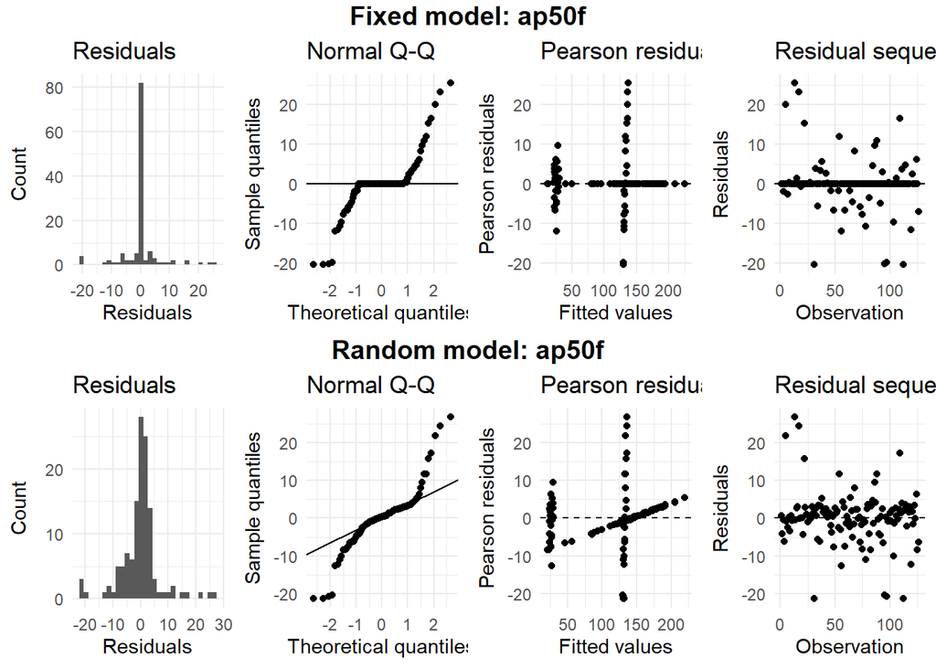

```
Linear mixed model fit by REML ['lmerMod']
Formula:
ap50m ~ 1 + (1 | block) + (1 | rows) + (1 | cols) + (1 | entry:checks) +
    (1 | geno)
   Data: dt.rm
Weights: weights

REML criterion at convergence: 1244.1

Scaled residuals:
    Min      1Q  Median      3Q     Max
-1.6601 -0.2884  0.0097  0.1432  3.3561

Random effects:
 Groups       Name        Variance         Std.Dev.
 entry:checks (Intercept) 2793.06726923897 52.8494775
 geno         (Intercept)    0.00006568558  0.0081047
 rows         (Intercept)    1.73309676909  1.3164713
 block        (Intercept)   34.65646942340  5.8869746
 cols         (Intercept)    0.00000003162  0.0001778
 Residual                  178.33654736483 13.3542708
Number of obs: 126, groups:
entry:checks, 80; geno, 79; rows, 24; block, 24; cols, 6

Fixed effects:
            Estimate Std. Error t value
(Intercept)  210.723      6.216    33.9
optimizer (nloptwrap) convergence code: 0 (OK)
boundary (singular) fit: see help('isSingular')
```

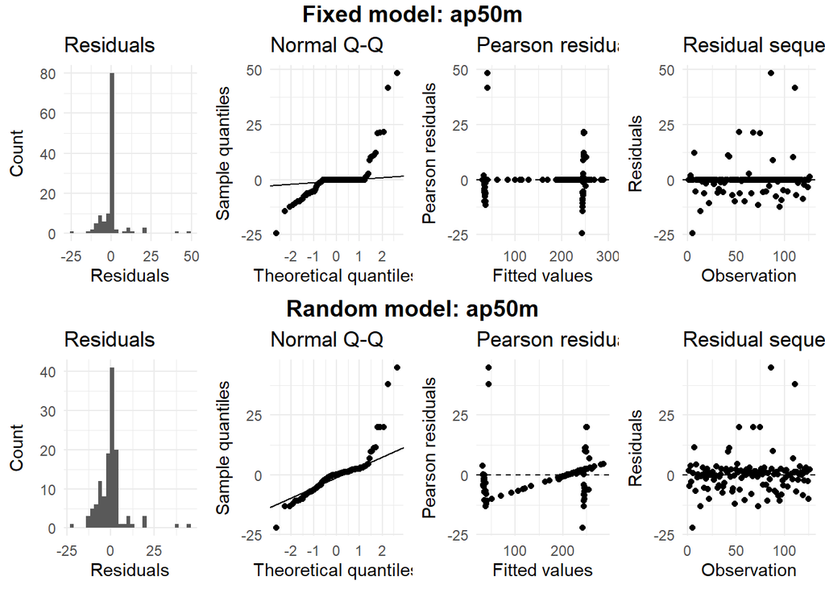

```
Linear mixed model fit by REML ['lmerMod']
Formula: dt ~ 1 + (1 | block) + (1 | rows) + (1 | cols) + (1 | entry:checks) +
    (1 | geno)
   Data: dt.rm
Weights: weights

REML criterion at convergence: 1635.5

Scaled residuals:
    Min      1Q  Median      3Q     Max
-4.9708 -0.3443 -0.0311  0.2860  6.7477

Random effects:
 Groups       Name        Variance Std.Dev.
 entry:checks (Intercept)  0.3561  0.5968
 geno         (Intercept) 28.6838  5.3557
 rows         (Intercept)  0.0000  0.0000
 block        (Intercept)  0.0000  0.0000
 cols         (Intercept)  0.0000  0.0000
 Residual                  1.9752  1.4054
Number of obs: 378, groups:
entry:checks, 80; geno, 79; rows, 24; block, 24; cols, 6

Fixed effects:
            Estimate Std. Error t value
(Intercept)   10.688      0.613   17.43
optimizer (nloptwrap) convergence code: 0 (OK)
boundary (singular) fit: see help('isSingular')
```

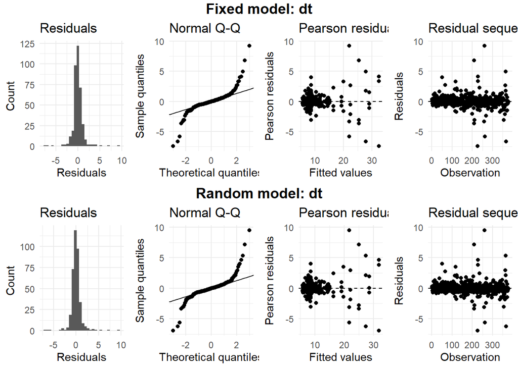

```
Linear mixed model fit by REML ['lmerMod']
Formula:
spad ~ 1 + (1 | block) + (1 | rows) + (1 | cols) + (1 | entry:checks) +
    (1 | geno)
   Data: dt.rm
Weights: weights

REML criterion at convergence: 2147.7

Scaled residuals:
     Min       1Q   Median       3Q      Max
-2.82788 -0.45427  0.07682  0.50421  2.44535

Random effects:
 Groups       Name        Variance    Std.Dev.
 entry:checks (Intercept)  8.07145596 2.841031
 geno         (Intercept)  6.50284509 2.550068
 rows         (Intercept)  0.00001242 0.003524
 block        (Intercept)  4.63926803 2.153896
 cols         (Intercept)  1.22031645 1.104679
 Residual                 10.82099999 3.289529
Number of obs: 378, groups:
entry:checks, 80; geno, 79; rows, 24; block, 24; cols, 6

Fixed effects:
            Estimate Std. Error t value
(Intercept)  45.3439     0.7917   57.27
```

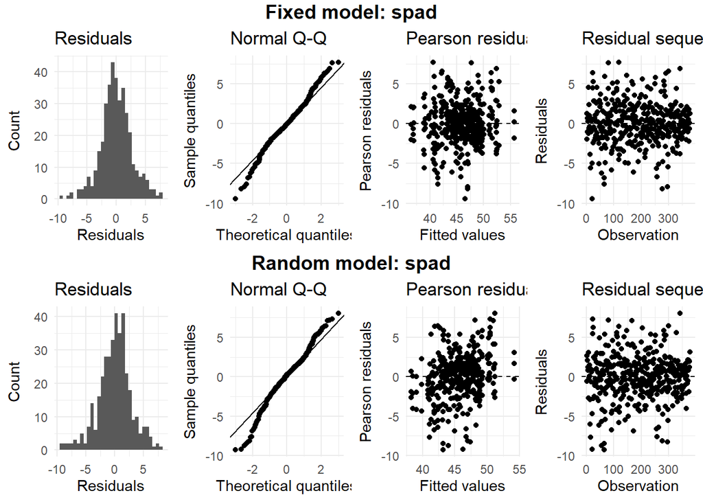

```
Linear mixed model fit by REML ['lmerMod']
Formula:
nrfp ~ 1 + (1 | block) + (1 | rows) + (1 | cols) + (1 | entry:checks) +
    (1 | geno)
   Data: dt.rm
Weights: weights

REML criterion at convergence: 707.7

Scaled residuals:
     Min       1Q   Median       3Q      Max
-1.84095 -0.20765 -0.06648  0.16773  2.09962

Random effects:
 Groups       Name        Variance       Std.Dev.
 entry:checks (Intercept)  2.97057869677 1.7235367
 geno         (Intercept) 40.01343013106 6.3256170
 rows         (Intercept)  0.01687346346 0.1298979
 block        (Intercept)  0.22810947243 0.4776081
 cols         (Intercept)  0.00000008147 0.0002854
 Residual                  2.30298762387 1.5175598
Number of obs: 126, groups:
entry:checks, 80; geno, 79; rows, 24; block, 24; cols, 6

Fixed effects:
            Estimate Std. Error t value
(Intercept)  13.1133     0.7636   17.17
```

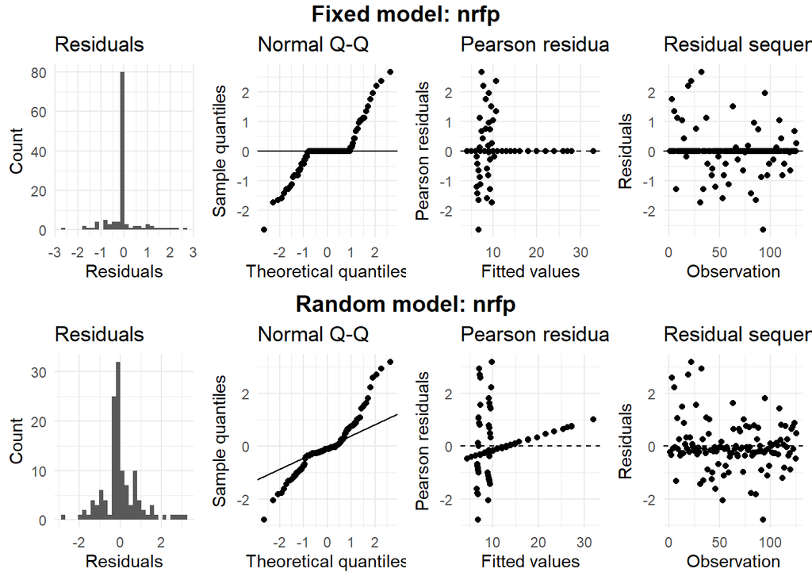

```
Linear mixed model fit by REML ['lmerMod']
Formula: df ~ 1 + (1 | block) + (1 | rows) + (1 | cols) + (1 | entry:checks) +
    (1 | geno)
   Data: dt.rm
Weights: weights

REML criterion at convergence: 816.3

Scaled residuals:
    Min      1Q  Median      3Q     Max
-3.9812 -0.0139 -0.0088  0.0465  0.5175

Random effects:
 Groups       Name        Variance   Std.Dev.
 entry:checks (Intercept) 133.542881 11.55608
 geno         (Intercept) 215.265387 14.67193
 rows         (Intercept)   0.006475  0.08047
 block        (Intercept)   0.002573  0.05073
 cols         (Intercept)   0.000000  0.00000
 Residual                   0.772791  0.87909
Number of obs: 126, groups:
entry:checks, 80; geno, 79; rows, 24; block, 24; cols, 6

Fixed effects:
            Estimate Std. Error t value
(Intercept)     87.5        2.1   41.66
optimizer (nloptwrap) convergence code: 0 (OK)
boundary (singular) fit: see help('isSingular')
```

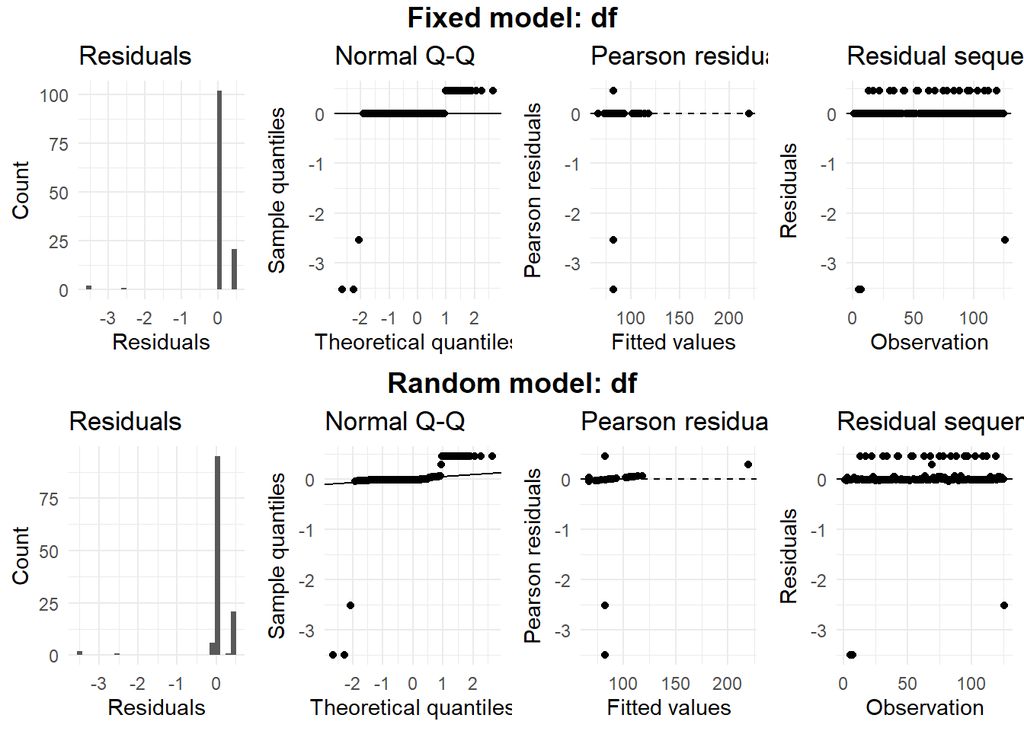

```
Linear mixed model fit by REML ['lmerMod']
Formula:
dflo ~ 1 + (1 | block) + (1 | rows) + (1 | cols) + (1 | entry:checks) +
    (1 | geno)
   Data: dt.rm
Weights: weights

REML criterion at convergence: 580.4

Scaled residuals:
     Min       1Q   Median       3Q      Max
-2.22107 -0.28789 -0.03326  0.12508  1.83471

Random effects:
 Groups       Name        Variance        Std.Dev.
 entry:checks (Intercept) 10.421028572583 3.22816179
 geno         (Intercept)  0.000000008112 0.00009007
 rows         (Intercept)  0.000000040336 0.00020084
 block        (Intercept)  0.000000000000 0.00000000
 cols         (Intercept)  0.000000000000 0.00000000
 Residual                  1.519817098253 1.23280862
Number of obs: 126, groups:
entry:checks, 80; geno, 79; rows, 24; block, 24; cols, 6

Fixed effects:
            Estimate Std. Error t value
(Intercept)  18.7885     0.3857   48.72
optimizer (nloptwrap) convergence code: 0 (OK)
boundary (singular) fit: see help('isSingular')
```

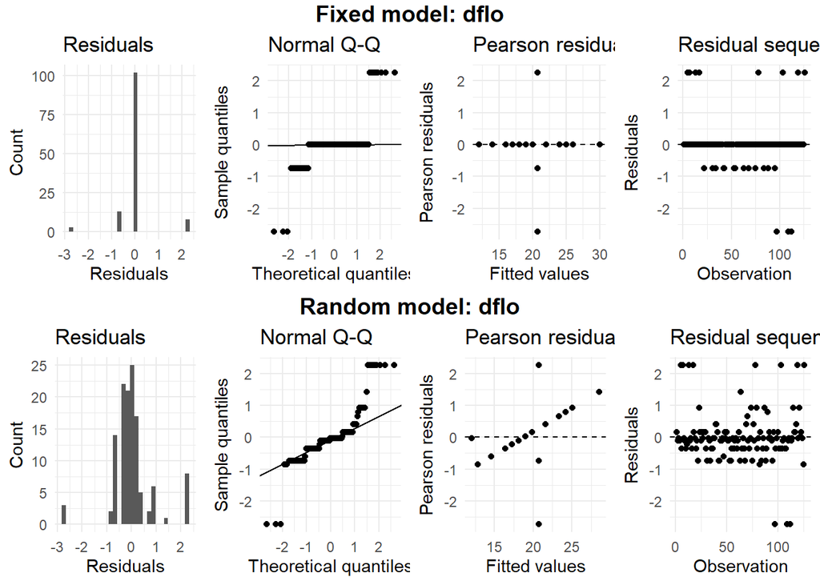

```
Linear mixed model fit by REML ['lmerMod']
Formula: lv ~ 1 + (1 | block) + (1 | rows) + (1 | cols) + (1 | entry:checks) +
    (1 | geno)
   Data: dt.rm
Weights: weights

REML criterion at convergence: 1769.5

Scaled residuals:
    Min      1Q  Median      3Q     Max
-5.0693 -0.6062 -0.0331  0.6008  3.3597

Random effects:
 Groups       Name        Variance      Std.Dev.
 entry:checks (Intercept) 6.41332822426 2.5324550
 geno         (Intercept) 0.00000002746 0.0001657
 rows         (Intercept) 0.08724621365 0.2953747
 block        (Intercept) 0.08629980255 0.2937683
 cols         (Intercept) 0.02919801233 0.1708743
 Residual                 0.53772349134 0.7332963
Number of obs: 630, groups:
entry:checks, 80; geno, 79; rows, 24; block, 24; cols, 6

Fixed effects:
            Estimate Std. Error t value
(Intercept)   13.834      0.306    45.2
optimizer (nloptwrap) convergence code: 0 (OK)
unable to evaluate scaled gradient
Model failed to converge: degenerate  Hessian with 1 negative eigenvalues
  See ?lme4::convergence and ?lme4::troubleshooting.
```

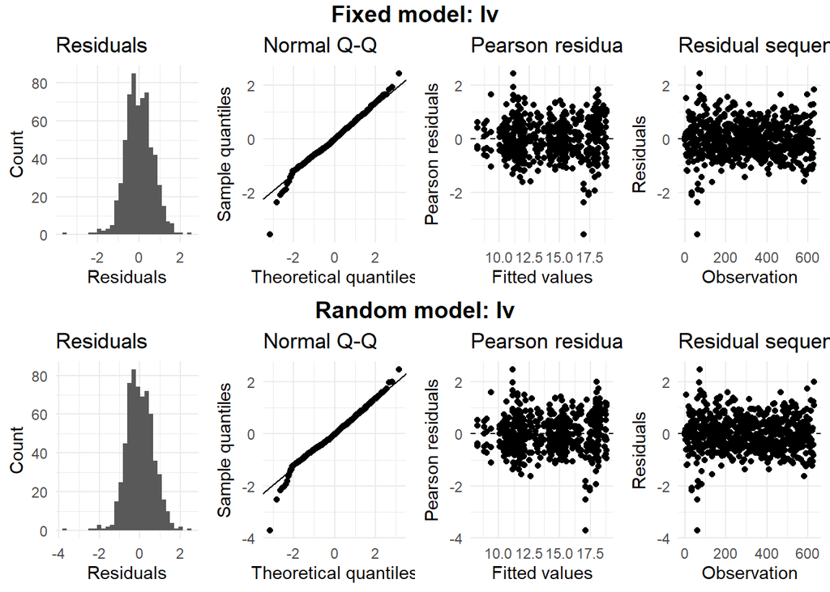

```
Linear mixed model fit by REML ['lmerMod']
Formula: vp ~ 1 + (1 | block) + (1 | rows) + (1 | cols) + (1 | entry:checks) +
    (1 | geno)
   Data: dt.rm
Weights: weights

REML criterion at convergence: 1271.9

Scaled residuals:
     Min       1Q   Median       3Q      Max
-2.24085 -0.09840 -0.04234  0.07138  2.20278

Random effects:
 Groups       Name        Variance       Std.Dev.
 entry:checks (Intercept)  235.927583080 15.359934
 geno         (Intercept) 5368.581451580 73.270604
 rows         (Intercept)    0.000008809  0.002968
 block        (Intercept)   37.403419685  6.115834
 cols         (Intercept)    0.000000000  0.000000
 Residual                  101.816751359 10.090429
Number of obs: 126, groups:
entry:checks, 80; geno, 79; rows, 24; block, 24; cols, 6

Fixed effects:
            Estimate Std. Error t value
(Intercept)    95.73       8.59   11.14
optimizer (nloptwrap) convergence code: 0 (OK)
boundary (singular) fit: see help('isSingular')
```

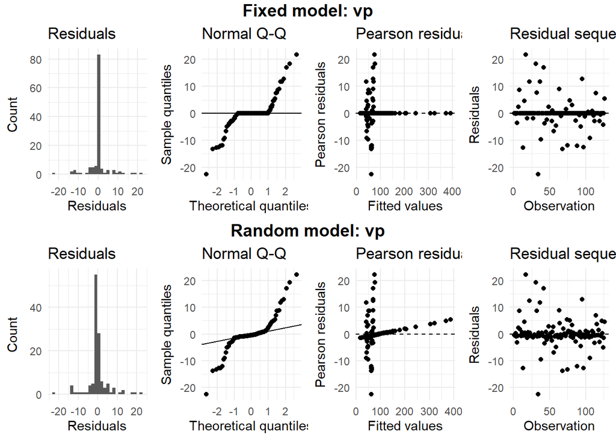

```
Linear mixed model fit by REML ['lmerMod']
Formula:
dhm ~ 1 + (1 | block) + (1 | rows) + (1 | cols) + (1 | entry:checks) +
    (1 | geno)
   Data: dt.rm
Weights: weights

REML criterion at convergence: 989.5

Scaled residuals:
     Min       1Q   Median       3Q      Max
-2.09354 -0.24285 -0.08592  0.19337  2.19196

Random effects:
 Groups       Name        Variance      Std.Dev.
 entry:checks (Intercept) 537.094208321 23.175293
 geno         (Intercept)   0.000078372  0.008853
 rows         (Intercept)   0.000000000  0.000000
 block        (Intercept)   0.000001935  0.001391
 cols         (Intercept)   0.134792900  0.367142
 Residual                  15.112643603  3.887498
Number of obs: 126, groups:
entry:checks, 80; geno, 79; rows, 24; block, 24; cols, 6

Fixed effects:
            Estimate Std. Error t value
(Intercept)  191.249      2.631    72.7
optimizer (nloptwrap) convergence code: 0 (OK)
boundary (singular) fit: see help('isSingular')
```

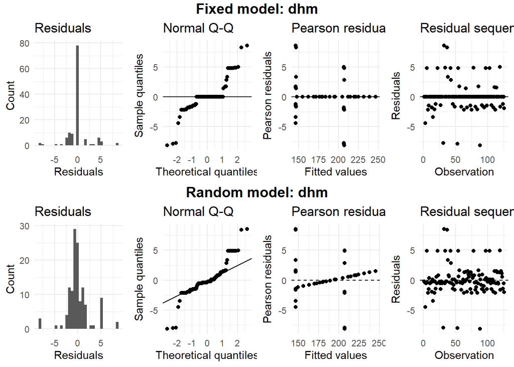

```
Linear mixed model fit by REML ['lmerMod']
Formula:
spv ~ 1 + (1 | block) + (1 | rows) + (1 | cols) + (1 | entry:checks) +
    (1 | geno)
   Data: dt.rm
Weights: weights

REML criterion at convergence: -918.5

Scaled residuals:
           Min             1Q         Median             3Q            Max
-0.00000274757 -0.00000003897  0.00000003232  0.00000029467  0.00000232315

Random effects:
 Groups       Name        Variance
 entry:checks (Intercept) 0.52343934875158404373962639510864391923
 geno         (Intercept) 0.39784756764712275733941737598797772080
 rows         (Intercept) 0.00000000000000000572148214033058147591
 block        (Intercept) 0.00000000000000000000000000000000005215
 cols         (Intercept) 0.00000000000000000181474540728387375614
 Residual                 0.00000000000087306718988288906559830371
 Std.Dev.
 0.723491084085757130140
 0.630751589492347441990
 0.000000002391961985553
 0.000000000000000007221
 0.000000001347124866998
 0.000000934380645070781
Number of obs: 126, groups:
entry:checks, 80; geno, 79; rows, 24; block, 24; cols, 6

Fixed effects:
            Estimate Std. Error t value
(Intercept)   5.7095     0.1078   52.97
optimizer (nloptwrap) convergence code: 0 (OK)
boundary (singular) fit: see help('isSingular')
```

[figure not shown]

```
Linear mixed model fit by REML ['lmerMod']
Formula: av ~ 1 + (1 | block) + (1 | rows) + (1 | cols) + (1 | entry:checks) +
    (1 | geno)
   Data: dt.rm
Weights: weights

REML criterion at convergence: 2310.5

Scaled residuals:
    Min      1Q  Median      3Q     Max
-4.3624 -0.5314  0.0078  0.5081  3.8684

Random effects:
 Groups       Name        Variance   Std.Dev.
 entry:checks (Intercept) 8.80436391 2.967215
 geno         (Intercept) 0.00001742 0.004173
 rows         (Intercept) 0.20593612 0.453802
 block        (Intercept) 0.80633753 0.897963
 cols         (Intercept) 0.36971549 0.608042
 Residual                 1.31490286 1.146692
Number of obs: 630, groups:
entry:checks, 80; geno, 79; rows, 24; block, 24; cols, 6

Fixed effects:
            Estimate Std. Error t value
(Intercept)  15.7336     0.4661   33.75
optimizer (nloptwrap) convergence code: 0 (OK)
unable to evaluate scaled gradient
Model failed to converge: degenerate  Hessian with 1 negative eigenvalues
  See ?lme4::convergence and ?lme4::troubleshooting.
```

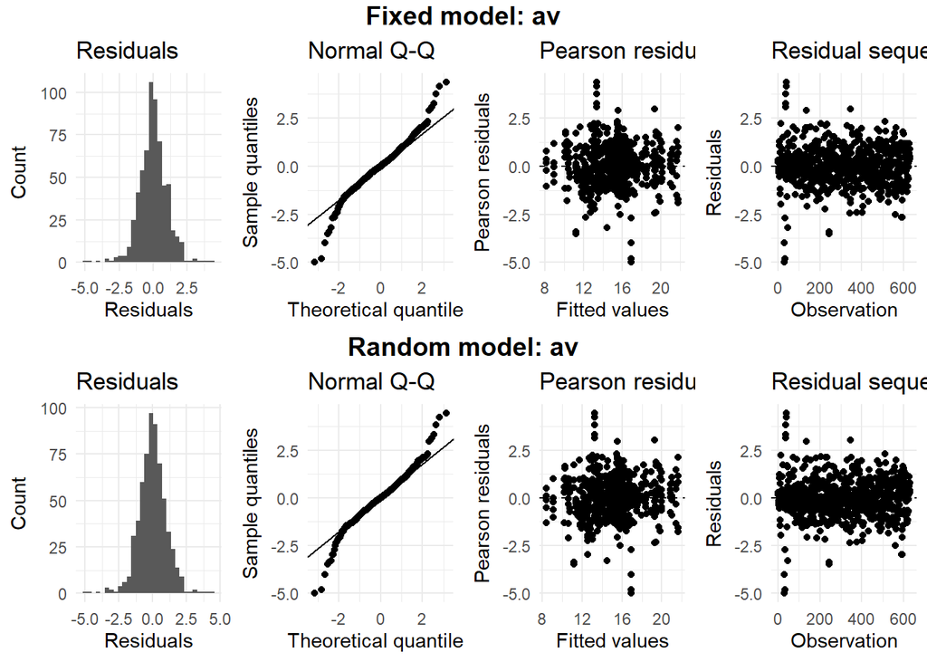

```
Linear mixed model fit by REML ['lmerMod']
Formula: ps ~ 1 + (1 | block) + (1 | rows) + (1 | cols) + (1 | entry:checks) +
    (1 | geno)
   Data: dt.rm
Weights: weights

REML criterion at convergence: 983.5

Scaled residuals:
     Min       1Q   Median       3Q      Max
-2.49340 -0.17664  0.01055  0.16384  1.94903

Random effects:
 Groups       Name        Variance      Std.Dev.
 entry:checks (Intercept) 207.719344584 14.4124718
 geno         (Intercept) 369.190479349 19.2143301
 rows         (Intercept)   0.000000384  0.0006197
 block        (Intercept)   0.000000000  0.0000000
 cols         (Intercept)   0.000000000  0.0000000
 Residual                  12.095253098  3.4778230
Number of obs: 126, groups:
entry:checks, 80; geno, 79; rows, 24; block, 24; cols, 6

Fixed effects:
            Estimate Std. Error t value
(Intercept)   95.168      2.726   34.91
optimizer (nloptwrap) convergence code: 0 (OK)
boundary (singular) fit: see help('isSingular')
```

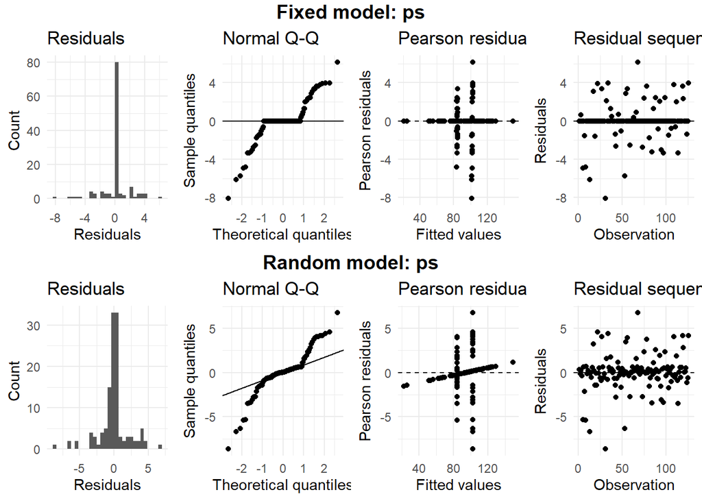

```
Linear mixed model fit by REML ['lmerMod']
Formula: ls ~ 1 + (1 | block) + (1 | rows) + (1 | cols) + (1 | entry:checks) +
    (1 | geno)
   Data: dt.rm
Weights: weights

REML criterion at convergence: 3734.3

Scaled residuals:
    Min      1Q  Median      3Q     Max
-7.7341 -0.5691 -0.0095  0.5163  3.2147

Random effects:
 Groups       Name        Variance        Std.Dev.
 entry:checks (Intercept) 0.1479698151929 0.38466845
 geno         (Intercept) 4.8964638472576 2.21279548
 rows         (Intercept) 0.0000000007102 0.00002665
 block        (Intercept) 0.0004268622322 0.02066064
 cols         (Intercept) 0.0000000000000 0.00000000
 Residual                 0.8731493659975 0.93442462
Number of obs: 1260, groups:
entry:checks, 80; geno, 79; rows, 24; block, 24; cols, 6

Fixed effects:
            Estimate Std. Error t value
(Intercept)  15.2476     0.2549   59.83
optimizer (nloptwrap) convergence code: 0 (OK)
boundary (singular) fit: see help('isSingular')
```

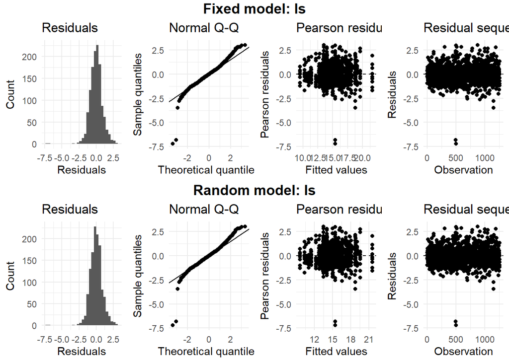

```
Linear mixed model fit by REML ['lmerMod']
Formula: as ~ 1 + (1 | block) + (1 | rows) + (1 | cols) + (1 | entry:checks) +
    (1 | geno)
   Data: dt.rm
Weights: weights

REML criterion at convergence: 2129.9

Scaled residuals:
    Min      1Q  Median      3Q     Max
-7.1010 -0.6307  0.0332  0.6449  3.3431

Random effects:
 Groups       Name        Variance     Std.Dev.
 entry:checks (Intercept) 1.3071548670 1.1433087
 geno         (Intercept) 0.0000037930 0.0019476
 rows         (Intercept) 0.0000001007 0.0003173
 block        (Intercept) 0.0122498578 0.1106791
 cols         (Intercept) 0.0003094638 0.0175916
 Residual                 0.2413468780 0.4912707
Number of obs: 1260, groups:
entry:checks, 80; geno, 79; rows, 24; block, 24; cols, 6

Fixed effects:
            Estimate Std. Error t value
(Intercept)   8.2725     0.1312   63.07
optimizer (nloptwrap) convergence code: 0 (OK)
unable to evaluate scaled gradient
Model failed to converge: degenerate  Hessian with 1 negative eigenvalues
  See ?lme4::convergence and ?lme4::troubleshooting.
```

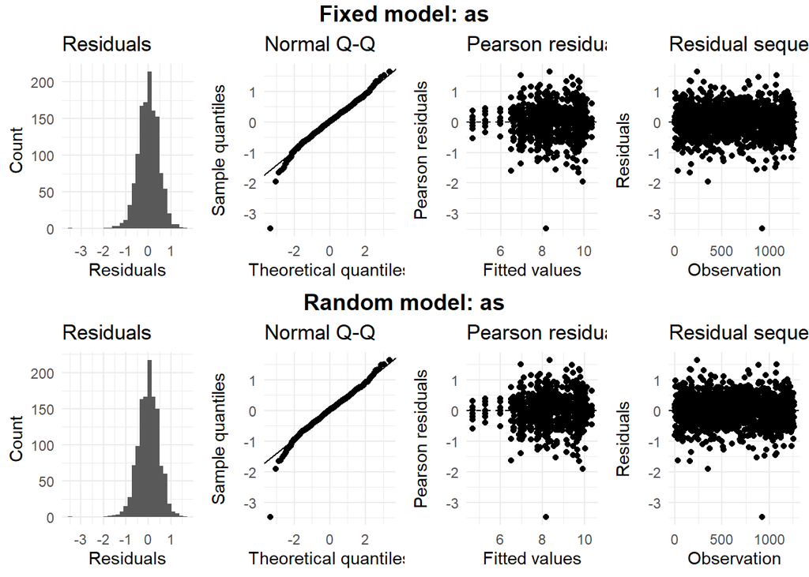

```
Linear mixed model fit by REML ['lmerMod']
Formula: rp ~ 1 + (1 | block) + (1 | rows) + (1 | cols) + (1 | entry:checks) +
    (1 | geno)
   Data: dt.rm
Weights: weights

REML criterion at convergence: 1563.3

Scaled residuals:
     Min       1Q   Median       3Q      Max
-1.75549 -0.18010 -0.05296  0.12905  2.49359

Random effects:
 Groups       Name        Variance    Std.Dev.
 entry:checks (Intercept)   856.74038  29.2701
 geno         (Intercept) 41167.92277 202.8988
 rows         (Intercept)   896.11307  29.9351
 block        (Intercept)     0.02268   0.1506
 cols         (Intercept)    46.92038   6.8498
 Residual                  1549.20010  39.3599
Number of obs: 126, groups:
entry:checks, 80; geno, 79; rows, 24; block, 24; cols, 6

Fixed effects:
            Estimate Std. Error t value
(Intercept)   288.14      24.44   11.79
optimizer (nloptwrap) convergence code: 0 (OK)
unable to evaluate scaled gradient
Model failed to converge: degenerate  Hessian with 1 negative eigenvalues
  See ?lme4::convergence and ?lme4::troubleshooting.
```

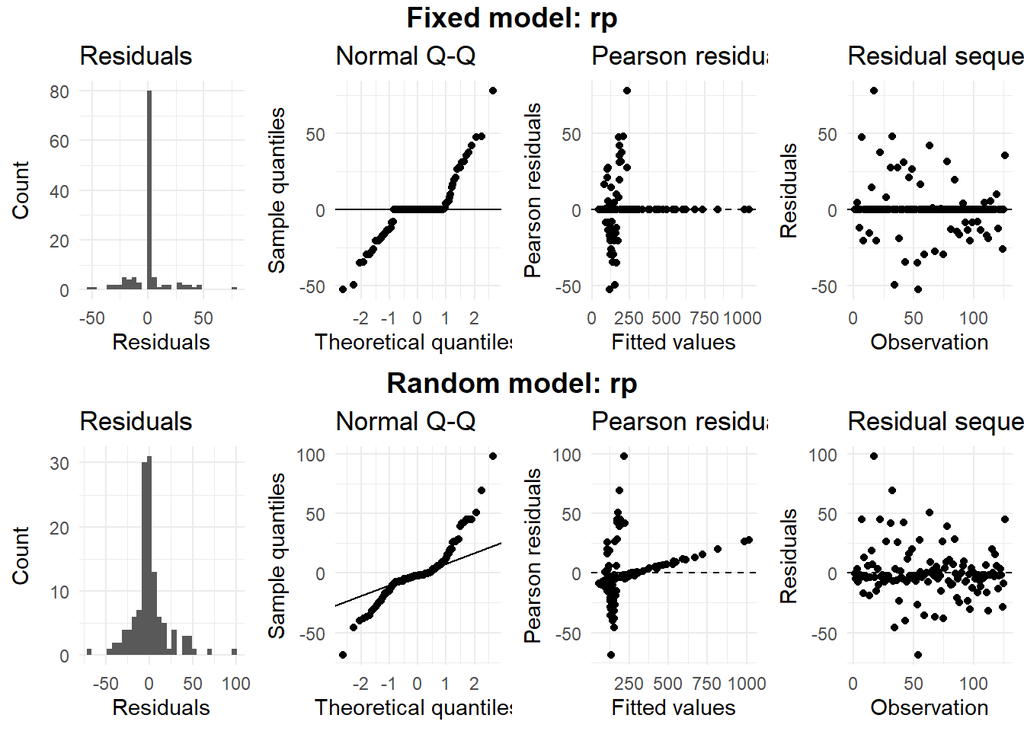

```
Linear mixed model fit by REML ['lmerMod']
Formula: hc ~ 1 + (1 | block) + (1 | rows) + (1 | cols) + (1 | entry:checks) +
    (1 | geno)
   Data: dt.rm
Weights: weights

REML criterion at convergence: 927.4

Scaled residuals:
     Min       1Q   Median       3Q      Max
-2.07188 -0.40236  0.04745  0.35739  2.21122

Random effects:
 Groups       Name        Variance      Std.Dev.
 entry:checks (Intercept)   4.903615851  2.214411
 geno         (Intercept) 127.888553267 11.308782
 rows         (Intercept)   0.000003597  0.001896
 block        (Intercept)   0.000021315  0.004617
 cols         (Intercept)   2.802961087  1.674205
 Residual                  31.398233191  5.603413
Number of obs: 126, groups:
entry:checks, 80; geno, 79; rows, 24; block, 24; cols, 6

Fixed effects:
            Estimate Std. Error t value
(Intercept)   42.140      1.594   26.44
```

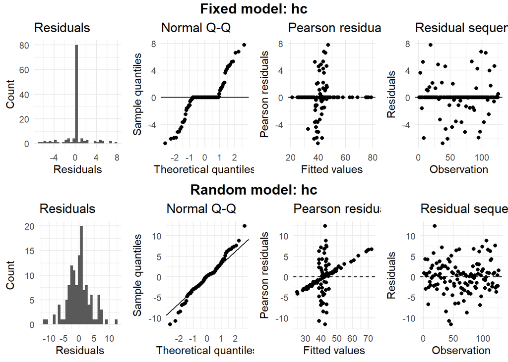

| trait | rep | geno | env | year | mean | std | min | max | V.g | V.e | V.p | repeatability | H2.s | H2.p | H2.c |
| --- | --- | --- | --- | --- | --- | --- | --- | --- | --- | --- | --- | --- | --- | --- | --- |
| ap50f | 1 | 79 | 1 | 1 | 144.29 | 43.57 | 14.12 | 226.38 | 197.99 | 131.86 | 329.85 | 0.6 | 0.6 | 0.06 | 0.1 |
| ap50m | 1 | 79 | 1 | 1 | 211.67 | 51.27 | 31.22 | 288.69 | 0 | 178.34 | 178.34 | 0 | 0 | 0 | 0 |
| dt | 1 | 79 | 1 | 1 | 10.69 | 5.45 | 5.63 | 32.37 | 28.68 | 1.98 | 30.66 | 0.94 | 0.94 | 0.98 | 0.97 |
| spad | 1 | 79 | 1 | 1 | 45.35 | 5.05 | 32.92 | 58.86 | 6.5 | 10.82 | 17.32 | 0.38 | 0.38 | 0.55 | 0.33 |
| nrfp | 1 | 79 | 1 | 1 | 13.11 | 6.83 | 3.61 | 33.53 | 40.01 | 2.3 | 42.32 | 0.95 | 0.95 | 0.94 | 0.88 |
| df | 1 | 79 | 1 | 1 | 87.54 | 18.7 | 67 | 220 | 215.27 | 0.77 | 216.04 | 1 | 1 | 0.78 | 0.62 |
| dflo | 1 | 79 | 1 | 1 | 18.83 | 3.37 | 12 | 30 | 0 | 1.52 | 1.52 | 0 | 0 | 0 | 0 |
| lv | 1 | 79 | 1 | 1 | 13.82 | 2.56 | 7.71 | 19.84 | 0 | 0.54 | 0.54 | 0 | 0 | 0 | 0 |
| vp | 1 | 79 | 1 | 1 | 95.75 | 75.6 | 10.82 | 397.23 | 5368.58 | 101.82 | 5470.4 | 0.98 | 0.98 | 0.97 | 0.94 |
| dhm | 1 | 79 | 1 | 1 | 191.44 | 23.06 | 148.12 | 247.12 | 0 | 15.11 | 15.11 | 0 | 0 | 0 | 0 |

[output cut: 7 more lines]

### 4.1.2 Adjusted means of checks

Because the checks were repeated across blocks, their adjusted means were estimated using a mixed linear model that accounted for the experimental variation associated with block and column effects. The checks were included as fixed effects, whereas block and column were considered random effects. The model was specified as:

$$y \sim 0 + (1|block) + (1|cols) + entry$$

where $y$ represents the observed value of each trait, $block$ represents the random block effect, $cols$ represents the random column effect, and $entry$ represents the fixed effect of the check. The model was fitted separately for each quantitative trait, and adjusted means were obtained as BLUEs (Best Linear Unbiased Estimates) for each check.

```
Linear mixed model fit by REML ['lmerMod']
Formula: ap50f ~ 1 + (1 | block) + (1 | cols) + (1 | entry)
   Data: dt.rm
Weights: weights

REML criterion at convergence: 378.9

Scaled residuals:
     Min       1Q   Median       3Q      Max
-1.80087 -0.52084  0.02614  0.40962  2.25248

Random effects:
 Groups   Name        Variance Std.Dev.
 block    (Intercept)   21.53   4.64
 cols     (Intercept)    0.00   0.00
 entry    (Intercept) 5737.00  75.74
 Residual              127.77  11.30
Number of obs: 48, groups:  block, 24; cols, 6; entry, 2

Fixed effects:
            Estimate Std. Error t value
(Intercept)    79.46      53.59   1.483
optimizer (nloptwrap) convergence code: 0 (OK)
boundary (singular) fit: see help('isSingular')
```

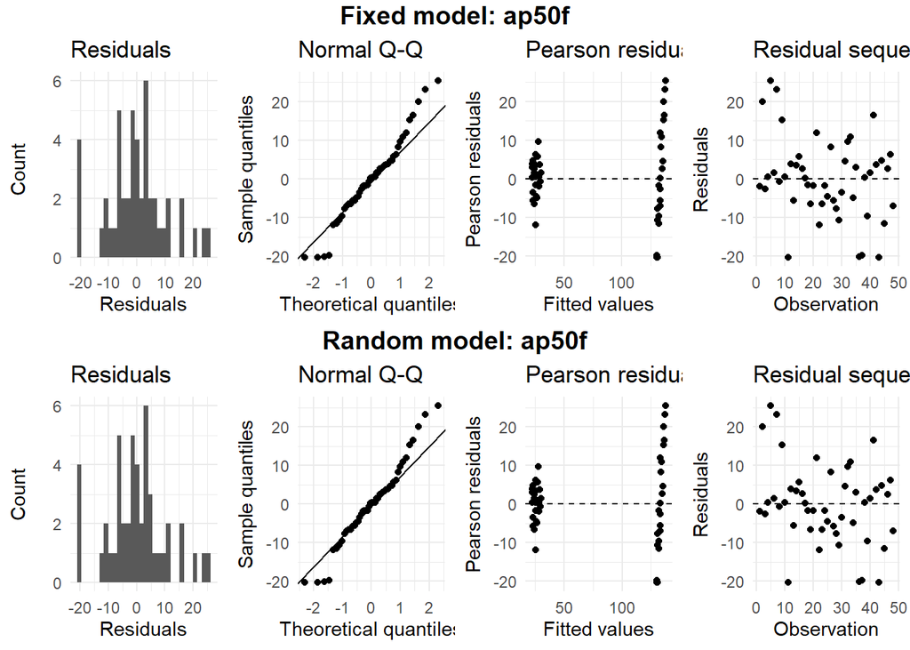

```
Linear mixed model fit by REML ['lmerMod']
Formula: ap50m ~ 1 + (1 | block) + (1 | cols) + (1 | entry)
   Data: dt.rm
Weights: weights

REML criterion at convergence: 397.5

Scaled residuals:
    Min      1Q  Median      3Q     Max
-1.7545 -0.4583 -0.2254  0.1028  3.4728

Random effects:
 Groups   Name        Variance       Std.Dev.
 block    (Intercept)    21.46002956   4.632497
 cols     (Intercept)     0.00006227   0.007891
 entry    (Intercept) 22363.03535517 149.542754
 Residual               194.62402742  13.950772
Number of obs: 48, groups:  block, 24; cols, 6; entry, 2

Fixed effects:
            Estimate Std. Error t value
(Intercept)    141.2      105.8   1.335
```

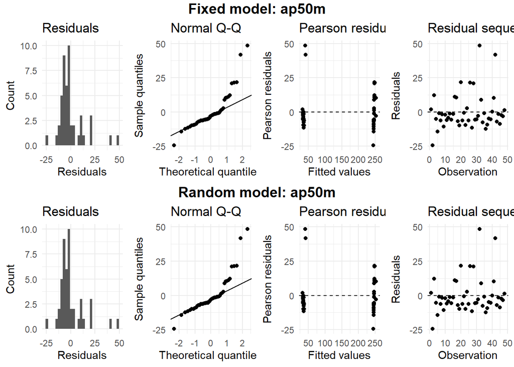

```
Linear mixed model fit by REML ['lmerMod']
Formula: dt ~ 1 + (1 | block) + (1 | cols) + (1 | entry)
   Data: dt.rm
Weights: weights

REML criterion at convergence: 96.4

Scaled residuals:
     Min       1Q   Median       3Q      Max
-1.55946 -0.67365  0.09396  0.44279  2.10079

Random effects:
 Groups   Name        Variance Std.Dev.
 block    (Intercept) 0.1587   0.3984
 cols     (Intercept) 0.0000   0.0000
 entry    (Intercept) 0.3706   0.6088
 Residual             0.2643   0.5141
Number of obs: 48, groups:  block, 24; cols, 6; entry, 2

Fixed effects:
            Estimate Std. Error t value
(Intercept)   8.1771     0.4443    18.4
optimizer (nloptwrap) convergence code: 0 (OK)
boundary (singular) fit: see help('isSingular')
```

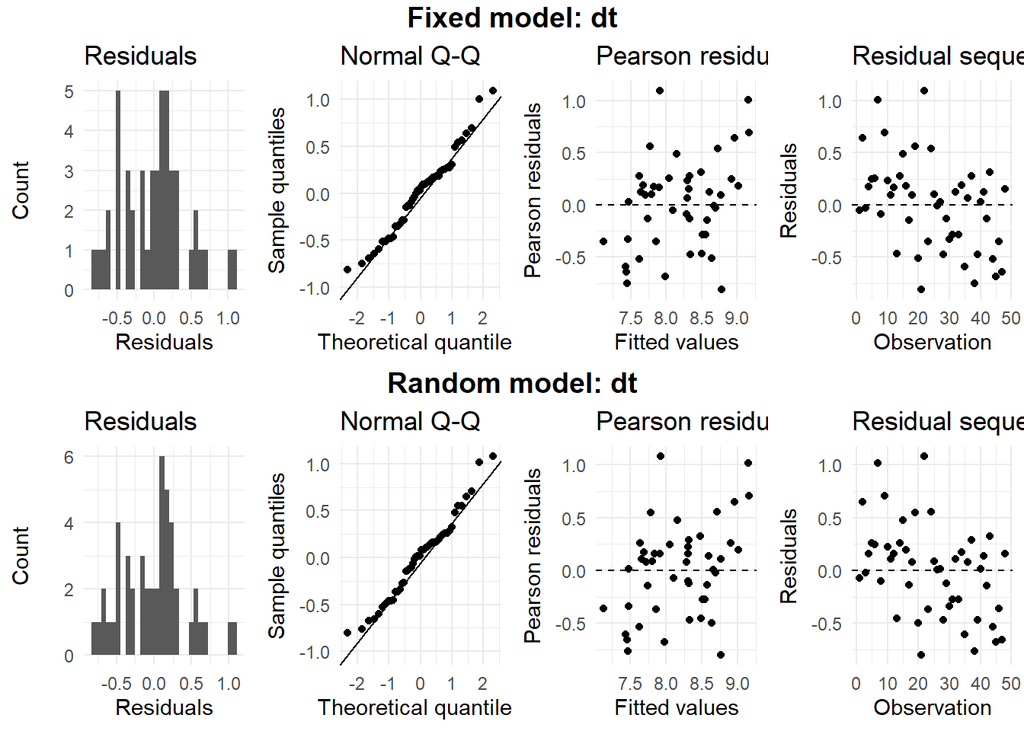

```
Linear mixed model fit by REML ['lmerMod']
Formula: spad ~ 1 + (1 | block) + (1 | cols) + (1 | entry)
   Data: dt.rm
Weights: weights

REML criterion at convergence: 282.6

Scaled residuals:
    Min      1Q  Median      3Q     Max
-2.1968 -0.5014  0.1990  0.6333  1.8649

Random effects:
 Groups   Name        Variance Std.Dev.
 block    (Intercept)  0.844   0.9187
 cols     (Intercept)  0.000   0.0000
 entry    (Intercept)  6.393   2.5284
 Residual             20.229   4.4977
Number of obs: 48, groups:  block, 24; cols, 6; entry, 2

Fixed effects:
            Estimate Std. Error t value
(Intercept)   46.515      1.911   24.34
optimizer (nloptwrap) convergence code: 0 (OK)
boundary (singular) fit: see help('isSingular')
```

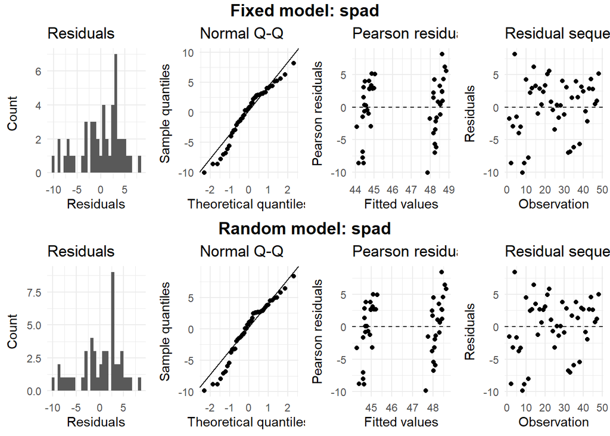

```
Linear mixed model fit by REML ['lmerMod']
Formula: nrfp ~ 1 + (1 | block) + (1 | cols) + (1 | entry)
   Data: dt.rm
Weights: weights

REML criterion at convergence: 183.3

Scaled residuals:
    Min      1Q  Median      3Q     Max
-1.9628 -0.6063 -0.1433  0.5895  1.9697

Random effects:
 Groups   Name        Variance Std.Dev.
 block    (Intercept) 0.7717   0.8785
 cols     (Intercept) 0.0000   0.0000
 entry    (Intercept) 2.9457   1.7163
 Residual             1.8252   1.3510
Number of obs: 48, groups:  block, 24; cols, 6; entry, 2

Fixed effects:
            Estimate Std. Error t value
(Intercept)    8.146      1.242   6.558
optimizer (nloptwrap) convergence code: 0 (OK)
boundary (singular) fit: see help('isSingular')
```

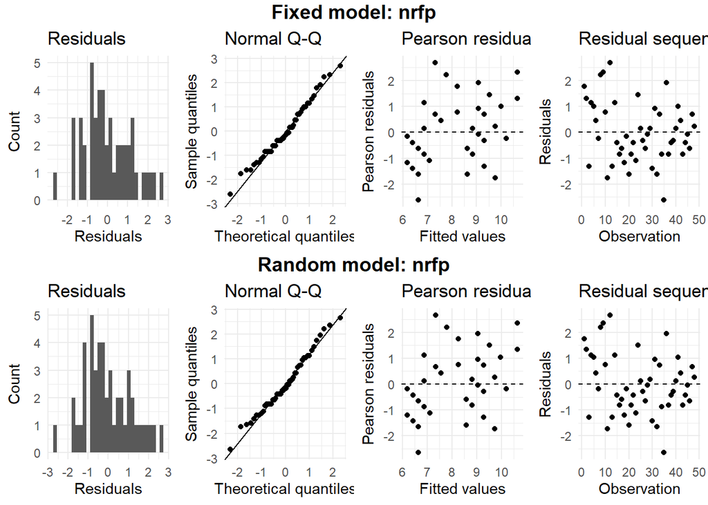

```
Linear mixed model fit by REML ['lmerMod']
Formula: df ~ 1 + (1 | block) + (1 | cols) + (1 | entry)
   Data: dt.rm
Weights: weights

REML criterion at convergence: 133.9

Scaled residuals:
    Min      1Q  Median      3Q     Max
-4.0034 -0.0024 -0.0024  0.5208  0.5208

Random effects:
 Groups   Name        Variance      Std.Dev.
 block    (Intercept)   0.000004872  0.002207
 cols     (Intercept)   0.000000000  0.000000
 entry    (Intercept) 120.739477238 10.988152
 Residual               0.781697978  0.884137
Number of obs: 48, groups:  block, 24; cols, 6; entry, 2

Fixed effects:
            Estimate Std. Error t value
(Intercept)   74.771      7.771   9.622
optimizer (nloptwrap) convergence code: 0 (OK)
boundary (singular) fit: see help('isSingular')
```

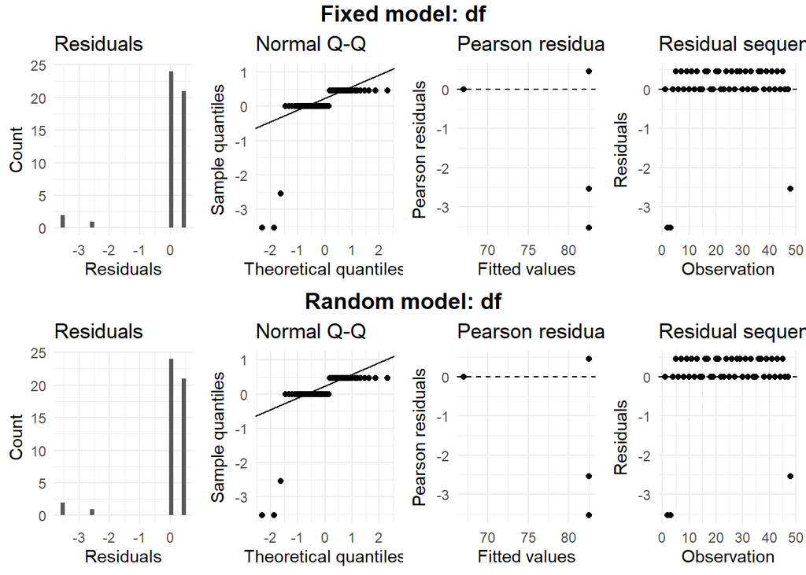

```
Linear mixed model fit by REML ['lmerMod']
Formula: dflo ~ 1 + (1 | block) + (1 | cols) + (1 | entry)
   Data: dt.rm
Weights: weights

REML criterion at convergence: 163.7

Scaled residuals:
     Min       1Q   Median       3Q      Max
-2.21521 -0.59986 -0.00603 -0.00576  1.82316

Random effects:
 Groups   Name        Variance      Std.Dev.
 block    (Intercept)  0.0003430295 0.0185211
 cols     (Intercept)  0.0000000139 0.0001179
 entry    (Intercept) 38.2248234255 6.1826227
 Residual              1.5322592807 1.2378446
Number of obs: 48, groups:  block, 24; cols, 6; entry, 2

Fixed effects:
            Estimate Std. Error t value
(Intercept)   16.375      4.375   3.742
optimizer (nloptwrap) convergence code: 0 (OK)
boundary (singular) fit: see help('isSingular')
```

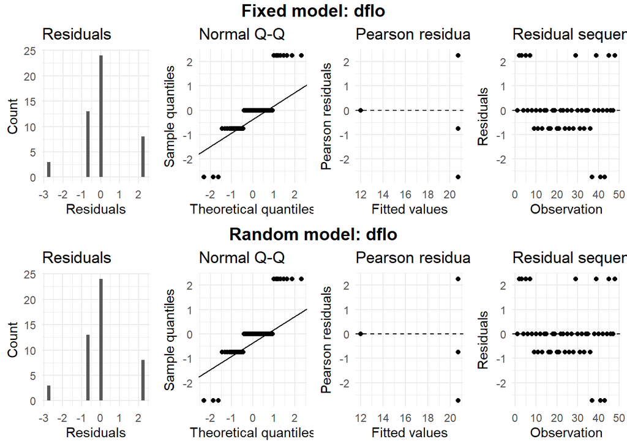

```
Linear mixed model fit by REML ['lmerMod']
Formula: lv ~ 1 + (1 | block) + (1 | cols) + (1 | entry)
   Data: dt.rm
Weights: weights

REML criterion at convergence: 117.9

Scaled residuals:
    Min      1Q  Median      3Q     Max
-4.0331 -0.3879 -0.0052  0.4922  1.6047

Random effects:
 Groups   Name        Variance Std.Dev.
 block    (Intercept)  0.0000  0.0000
 cols     (Intercept)  0.0000  0.0000
 entry    (Intercept) 19.8201  4.4520
 Residual              0.5742  0.7578
Number of obs: 48, groups:  block, 24; cols, 6; entry, 2

Fixed effects:
            Estimate Std. Error t value
(Intercept)    14.83       3.15   4.708
optimizer (nloptwrap) convergence code: 0 (OK)
boundary (singular) fit: see help('isSingular')
```

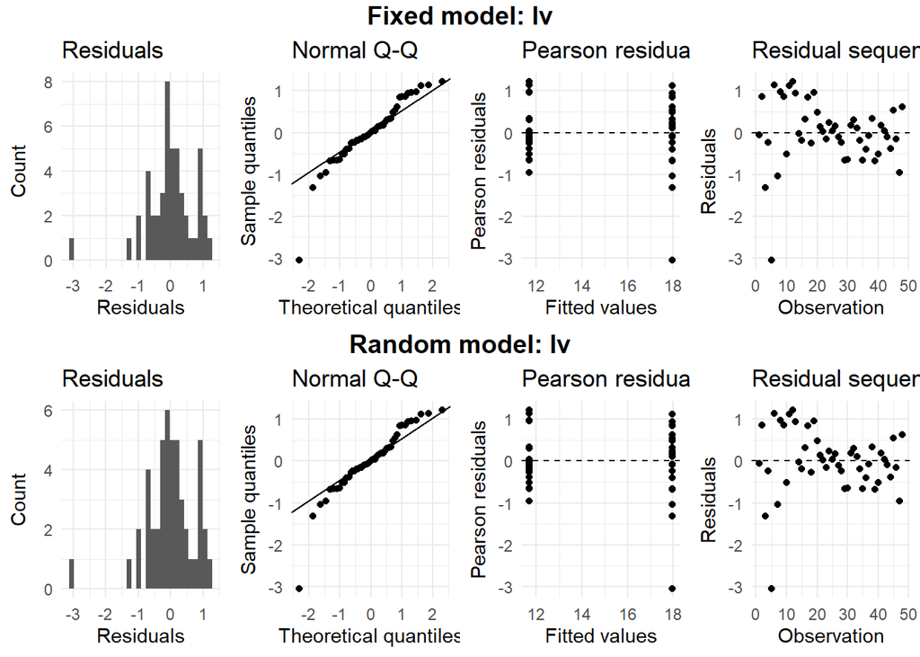

```
Linear mixed model fit by REML ['lmerMod']
Formula: vp ~ 1 + (1 | block) + (1 | cols) + (1 | entry)
   Data: dt.rm
Weights: weights

REML criterion at convergence: 371.3

Scaled residuals:
     Min       1Q   Median       3Q      Max
-2.26832 -0.38114 -0.06875  0.46369  2.18106

Random effects:
 Groups   Name        Variance        Std.Dev.
 block    (Intercept)  40.66086289230  6.3765871
 cols     (Intercept)   0.00000003444  0.0001856
 entry    (Intercept) 232.40576187192 15.2448602
 Residual              99.66298498140  9.9831350
Number of obs: 48, groups:  block, 24; cols, 6; entry, 2

Fixed effects:
            Estimate Std. Error t value
(Intercept)    55.42      10.95   5.059
optimizer (nloptwrap) convergence code: 0 (OK)
boundary (singular) fit: see help('isSingular')
```

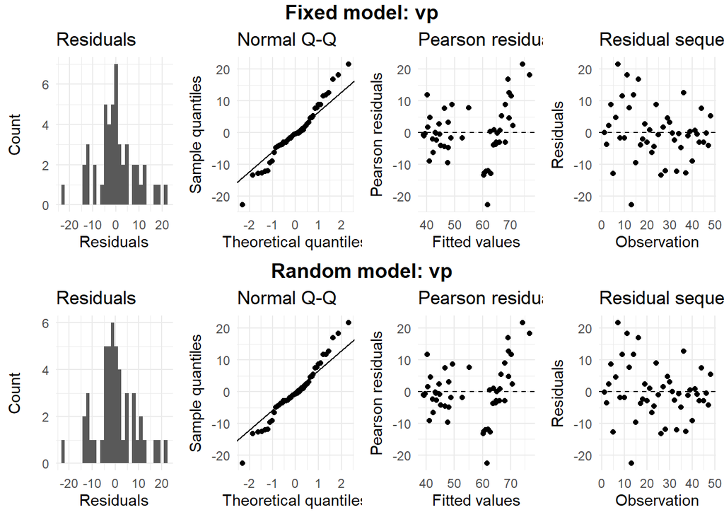

```
Linear mixed model fit by REML ['lmerMod']
Formula: dhm ~ 1 + (1 | block) + (1 | cols) + (1 | entry)
   Data: dt.rm
Weights: weights

REML criterion at convergence: 273.3

Scaled residuals:
    Min      1Q  Median      3Q     Max
-2.1137 -0.4698 -0.3692  0.7563  2.2191

Random effects:
 Groups   Name        Variance  Std.Dev.
 block    (Intercept)    0.0000  0.0000
 cols     (Intercept)    0.2506  0.5006
 entry    (Intercept) 1832.6250 42.8092
 Residual               15.0468  3.8790
Number of obs: 48, groups:  block, 24; cols, 6; entry, 2

Fixed effects:
            Estimate Std. Error t value
(Intercept)   176.78      30.28   5.839
optimizer (nloptwrap) convergence code: 0 (OK)
boundary (singular) fit: see help('isSingular')
```

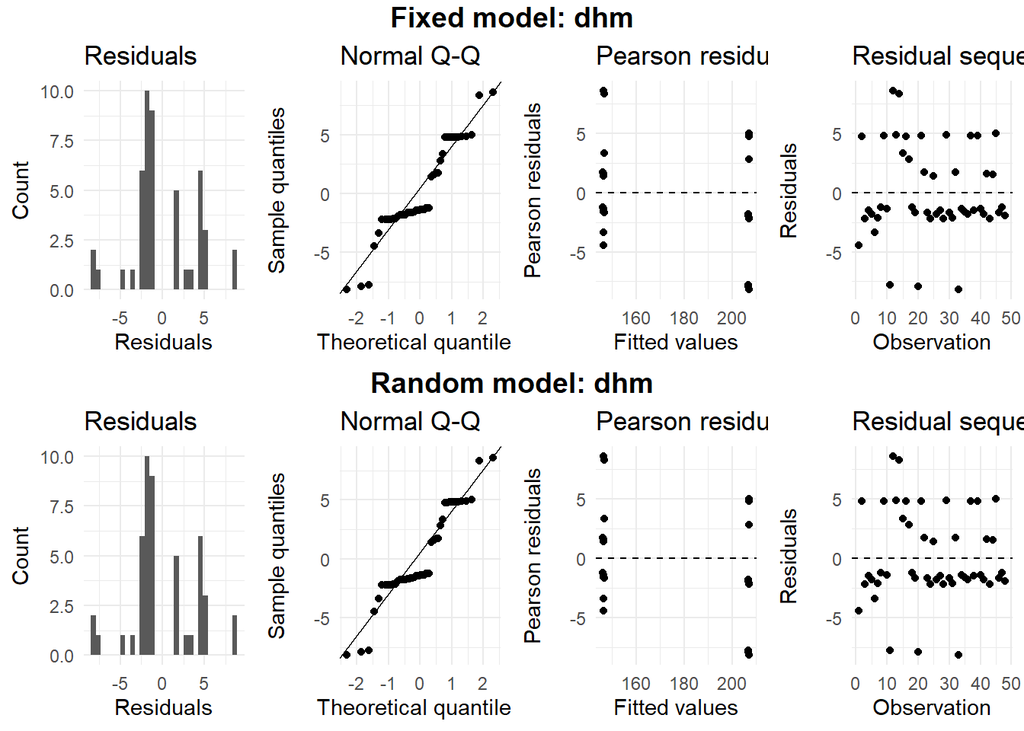

```
Linear mixed model fit by REML ['lmerMod']
Formula: spv ~ 1 + (1 | block) + (1 | cols) + (1 | entry)
   Data: dt.rm
Weights: weights

REML criterion at convergence: -1387.8

Scaled residuals:
           Min             1Q         Median             3Q            Max
-0.00000012463 -0.00000012463 -0.00000001385  0.00000009693  0.00000009693

Random effects:
 Groups   Name        Variance             Std.Dev.
 block    (Intercept) 0.000000000000000000 0.00000000000
 cols     (Intercept) 0.000000000000000000 0.00000000000
 entry    (Intercept) 0.010639193276588407 0.10314646517
 Residual             0.000000000000004114 0.00000006414
Number of obs: 48, groups:  block, 24; cols, 6; entry, 2

Fixed effects:
            Estimate Std. Error t value
(Intercept)  5.50459    0.07288   75.53
optimizer (nloptwrap) convergence code: 0 (OK)
boundary (singular) fit: see help('isSingular')
```

[figure not shown]

```
Linear mixed model fit by REML ['lmerMod']
Formula: av ~ 1 + (1 | block) + (1 | cols) + (1 | entry)
   Data: dt.rm
Weights: weights

REML criterion at convergence: 183.4

Scaled residuals:
    Min      1Q  Median      3Q     Max
-3.5778 -0.5716 -0.0020  0.4959  3.0351

Random effects:
 Groups   Name        Variance        Std.Dev.
 block    (Intercept) 0.0000000000000 0.0000000
 cols     (Intercept) 0.0000000009241 0.0000304
 entry    (Intercept) 6.6441877510807 2.5776322
 Residual             2.4438364717109 1.5632775
Number of obs: 48, groups:  block, 24; cols, 6; entry, 2

Fixed effects:
            Estimate Std. Error t value
(Intercept)   14.124      1.837    7.69
optimizer (nloptwrap) convergence code: 0 (OK)
boundary (singular) fit: see help('isSingular')
```

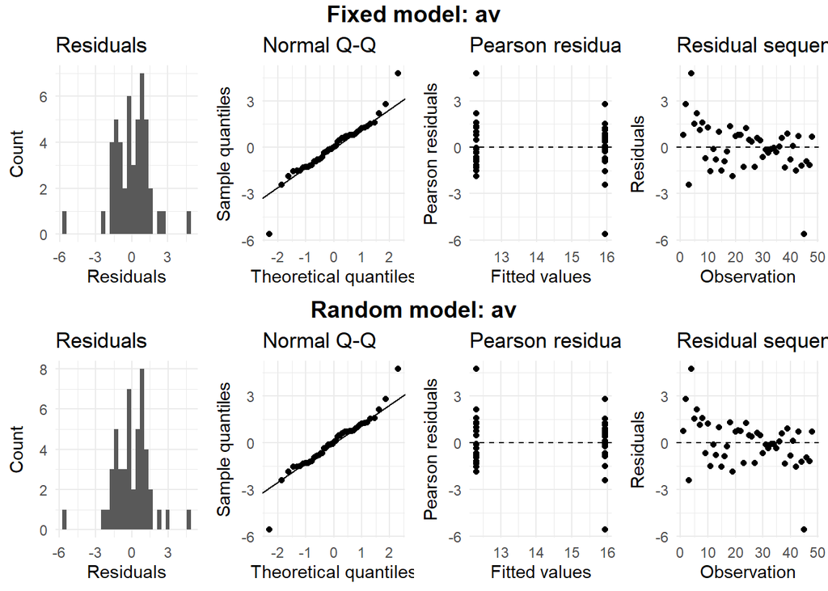

```
Linear mixed model fit by REML ['lmerMod']
Formula: ps ~ 1 + (1 | block) + (1 | cols) + (1 | entry)
   Data: dt.rm
Weights: weights

REML criterion at convergence: 260

Scaled residuals:
    Min      1Q  Median      3Q     Max
-2.4392 -0.5873  0.1235  0.7308  1.8439

Random effects:
 Groups   Name        Variance Std.Dev.
 block    (Intercept)   1.014   1.007
 cols     (Intercept)   0.000   0.000
 entry    (Intercept) 163.207  12.775
 Residual              11.075   3.328
Number of obs: 48, groups:  block, 24; cols, 6; entry, 2

Fixed effects:
            Estimate Std. Error t value
(Intercept)   93.296      9.049   10.31
optimizer (nloptwrap) convergence code: 0 (OK)
boundary (singular) fit: see help('isSingular')
```

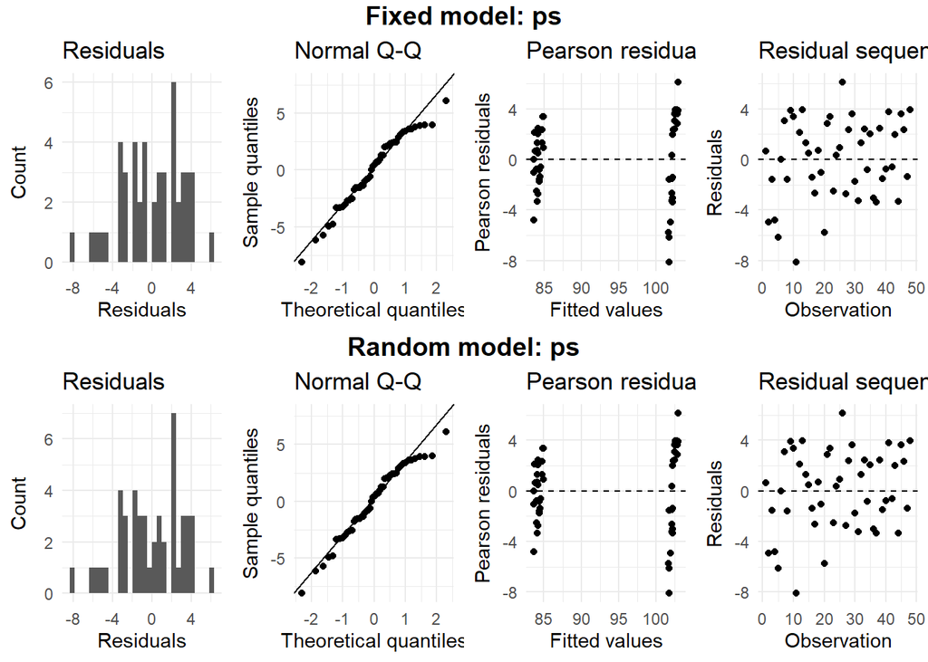

```
Linear mixed model fit by REML ['lmerMod']
Formula: ls ~ 1 + (1 | block) + (1 | cols) + (1 | entry)
   Data: dt.rm
Weights: weights

REML criterion at convergence: 34.1

Scaled residuals:
    Min      1Q  Median      3Q     Max
-2.3515 -0.6610 -0.2117  0.9246  1.7267

Random effects:
 Groups   Name        Variance Std.Dev.
 block    (Intercept) 0.0000   0.0000
 cols     (Intercept) 0.0000   0.0000
 entry    (Intercept) 0.1460   0.3821
 Residual             0.1032   0.3212
Number of obs: 48, groups:  block, 24; cols, 6; entry, 2

Fixed effects:
            Estimate Std. Error t value
(Intercept)  13.7617     0.2742    50.2
optimizer (nloptwrap) convergence code: 0 (OK)
boundary (singular) fit: see help('isSingular')
```

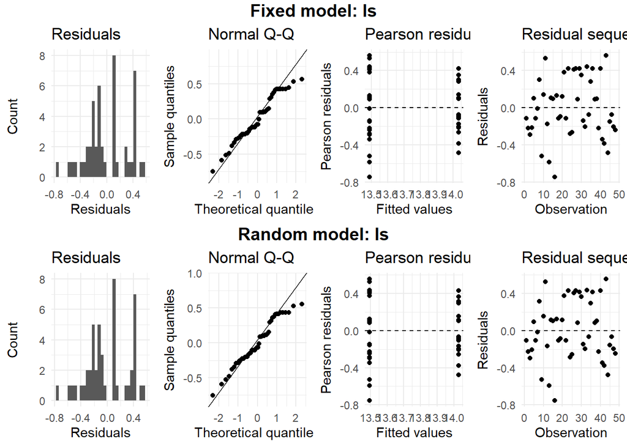